# Tutorial 2

Matthias Nijman - S4667999

## 1

### 1A-I

Throwing one on every throw from the 10th throw onward

### 1A-II

Throwing one on any throw after the 5th

### 1A-III

Throwing anything but one on the 4th throw and then throwing one every time afterwards. *Anything but one on the first 4. See the cap not cup.*

### 1B

$$\left( \bigcup_{i>n} \varepsilon_i \right)
\;\cap\;
\left( \bigcap_{i \le n} \varepsilon_i^{c} \right)$$

## 2

10 balls, 6 white, 4 red. R = red Probability of red on pick 2 given red on pick 1 = $(R_2|R_1)$ After the first pick we have 9 balls, of which 3 are red. Thus $P(R_2|R_1) = \frac{3}{9}$. *It should be $P(R_b|R_1 \cup R_2) = \frac{P(R_b)}{P(R_1) + P(R2) - P(R_b)} =\frac{1}{5}$. Mind that $P(R_b) = P(R_1) \cap P(R_2) = P(R_1) \times P(R_2)$*

## 3

$B_1$ has 8 red, 5 blue, total 13 $B_2$ has 6 red, 4 blue, total 10 We roll a fair die, 1 = $B_1$, other = $B_2$

### 3A

$P(R) = P(R|B_1)P(B_1) + P(R|B_2)P(B_2)$  
$P(B_1) = \frac{1}{6}$  
$P(B_2) = \frac{5}{6}$  
$P(R|B_1) = \frac{8}{13}$  
$P(R|B_2) = \frac{6}{10}$  
$P(R) = \frac{8}{13}\frac{1}{6} + \frac{6}{10}\frac{5}{6}$

```r
library(MASS)
p = (8/13*(1/6)) + (6/10*5/6)
fractions(p)
```

```
[1] 47/78
```

### 3B

After drawing from a bag we keep drawing from that bag. $P(R_1 \& R_2) = (\frac{8}{13})^2 \frac{1}{6} + (\frac{6}{10})^2 \frac{5}{6}$

```r
library(MASS)
p = ((8/13)^2*(1/6)) + ((6/10)^2*5/6)
fractions(p)
```

```
[1] 1841/5070
```

### 3C

We are drawing with replacement, thus the chances remain the same after each draw. Drawing red twice is $P(R)^2$ thus $(\frac{47}{78})^2$

```r
fractions((47/78)^2)
```

```
[1] 2209/6084
```

```r
(47/78)^2
```

```
[1] 0.3630835
```

## 4

### 4A

```r
sample(x=c("H","T"), size=10, replace=TRUE)
```

```
 [1] "H" "T" "H" "H" "T" "H" "T" "T" "T" "H"
```

We got 5 H and 5 T, The ratio of H is $\frac{5}{10} = \frac{1}{2}$

### 4B

```r
calculate_head_ratio <- function(n) {
  tosses <- sample(x=c("H","T"), size=n, replace=TRUE)
  count <- 0
  for (x in tosses) {
    if (x == "H") {
      count <- count +1
    }
  }
  return (count/length(tosses))
}
```

### 4C

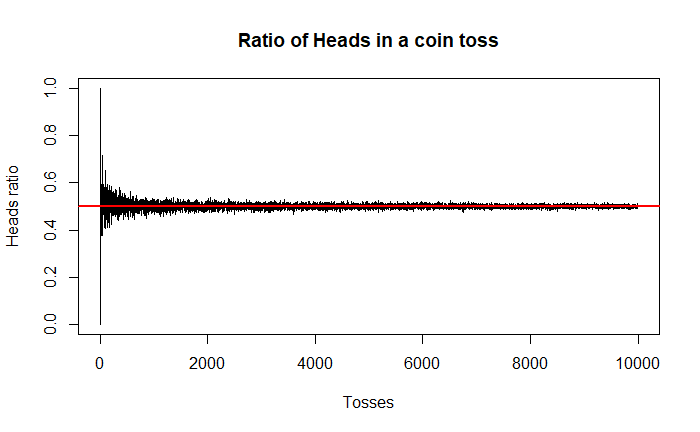

```r
results <- sapply(1:10000, calculate_head_ratio)
# Added: type='l' and abline(h=0.5,col='red',lwd=2)
plot(results, type='l', main="Ratio of Heads in a coin toss", xlab="Tosses", ylab="Heads ratio")
abline(h=0.5,col='red',lwd=2)
```

The plot shows that as the number of throws goes up, the ratio gets closer to 0.5

### 5A

We will use $B$ for buying and $C$ for customer, and then 1, 2 and 3 for the category.  
$P(B) = P(B|C_1)+P(B|C_2)+P(B|C_3)$  
We know that $P(B|C_1)=0.4$, $P(B|C_2)=0.13$, $P(B|C_3)=0.08$, thus $P(B) = 0.4+0.13+0.08=0.61$. *Law of total prob: $P (ε) = P (ε | C1)P (C1) + P (ε | C2)P (C2) + P (ε | C3)P (C3)$*

### 5B

$P(C_3) = 0.25$ Using Bayes’ Formula, we know that:  
$P(C_3|B) = \frac{P(B|C_3)P(C_3)}{P(B)} = \frac{P(0.08)P(0.25)}{P(0.61)}$

```r
0.08*0.25/0.61
```

```
[1] 0.03278689
```

```r
fractions(0.08*0.25/0.61)
```

```
[1] 2/61
```

$P(C_3|B) = 0.03278689 = \frac{2}{61}$

### 6A

The probability the student answers correctly on a question they knew the answer to. In this case 1.

### 6B

The probability a student knew the question given they answered it correctly.

### 6C

$P(R) = \frac{1}{N}+0.7$  
$P(K|R) > \frac{P(R|K)P(K)}{P(R)}$  
$0.99 > \frac{1\times0.7}{\frac{1}{N}+0.7}$  
$\frac{1}{N} < \frac{0.7}{0.99} - 0.7$  
$N < 141.4$

*$\frac{7N}{7N+3}> 0.99$ so N > 43*

## 7

### 7A

They are independent if $P(\epsilon_1\cap\epsilon_2)=P(\epsilon_1)P(\epsilon_2)$. We know $P(\epsilon_1\cap\epsilon_2)=0.65$ and $P(\epsilon_1)P(\epsilon_2)=0.5\times0.2=0.1$. This means they are not independent.

### 7B

$P(\epsilon_1\cap\epsilon_2)\geq P(\epsilon_1) + P(\epsilon_2) - 1$  
$P(\epsilon_1) + P(\epsilon_2) - 1 = 0.8 + 0.4 - 1 = 0.2$  
The statement is correct.

### 7C

Events are independent if $P(\epsilon_1\cap\epsilon_2)=P(\epsilon_1)P(\epsilon_2)$.  
And $P(\epsilon_1\cap\epsilon_2)= P(\epsilon_1) + P(\epsilon_2) - 1$.

For $\emptyset$:  
$P(\emptyset\cap\epsilon)= P(\emptyset) + P(\epsilon) - 1$  
$0 + P(\epsilon) - 1 \leq 0$ this intersection cannot be smaller than 0 in reality, so it will equal 0.  
$P(\emptyset)P(\epsilon) = 0\times P(\epsilon) = 0$.  
$P(\emptyset\cap\epsilon)=P(\emptyset)P(\epsilon)$ is satisfied, thus $\emptyset$ is independent from any event.

For $\Omega$:  
$P(\Omega\cap\epsilon)= P(\Omega) + P(\epsilon) - 1$  
$1 + P(\epsilon) - 1 = P(\epsilon)$  
$P(\Omega)P(\epsilon) = 1\times P(\epsilon) = P(\epsilon)$.  
$P(\Omega\cap\epsilon)=P(\Omega)P(\epsilon)$ is satisfied, thus $\Omega$ is independent from any event.

### 7D

All three are independent, so $P(\epsilon_1\cap\epsilon_2\cap\epsilon_3) = P(\epsilon_1) P(\epsilon_2) P(\epsilon_3)$.  
That means we can say that $P((\epsilon_1\cap\epsilon_2)\cap\epsilon_3)=(P(\epsilon_1)P(\epsilon_2))P(\epsilon_3)$.  
Which means they are independent.